# EPR & Bell

Study Notes

Jay (notetaker)

last updated on: 2021-11-21

Source

1. Lecture 3-4 [EPR Paradox](https://www.youtube.com/watch?v=Lu8cEBxupXY) and Lecture 4-1 to 4-4.
2. [Wiki](https://en.wikipedia.org/wiki/EPR_paradox)
3. https://www.thoughtco.com/epr-paradox-in-physics-2699186
4. [EPR’s Paradox Exemplified: Bohm’s Spin Experiment](https://entangledphysics.com/2015/05/10/eprs-paradox-exemplified-bohms-spin-experiment/)
5. [Entanglement (I): how it all began, the EPR Paradox](https://entangledphysics.com/2015/03/28/entanglement-how-it-all-began-the-epr-paradox/)

# 1 The Paradox

EPR paradox is a thought experiment proposed by Einstein–Podolsky–Rosen. They used the paradox to argue that the description of physical reality provided by quantum mechanics was incomplete.

Later, Bohm explained the EPR paradox using an much simpler example. Below we will use similar example to help understand the ERP paradox

The paradox involves a pair of entangled qubits.

$$|++\rangle = \frac{1}{2}(|0\rangle + |1\rangle)(|0\rangle + |1\rangle)$$
$$|--\rangle = \frac{1}{2}(|0\rangle - |1\rangle)(|0\rangle - |1\rangle)$$

$$\begin{aligned}
|\psi\rangle &= \frac{1}{\sqrt{2}}(|00\rangle + |11\rangle) \\
&= \frac{1}{\sqrt{2}}(|++\rangle + |--\rangle)
\end{aligned}$$

Let Alice keep the first qubit and Bob the second, and let them be light years apart.

As soon as Alice makes a bit-measurement (Z-measurement/position; $|0\rangle$ or $|1\rangle$), Bob can predict his bit-measurement result. Same is true if Alice performs a sign-measurement (X-measure/momentum; $|+\rangle$ or $|-\rangle$)

The assumption of the paradox is *Local Realism*.

Locality: since the two qubits are far apart, measurement on one qubit cannot affect/disturb the other.

Realism: if the outcome of a measurement is know before the measurement takes place, there must be “an element of reality” (hidden variables) that pre-determines the measurement outcome.

> *I think that matter must have a separate reality independent of the measurements. That is an electron has spin, location and so forth even when it is not being measured. I like to think that the moon is there even if I am not looing at it.*

# 2 Bell’s theorm

An experiment to test whether “local realism” or QM is true. The answer is QM. The test can be expressed using inequalities known as “Bell’s inequalities.”

“The present view of the situation is that quantum mechanics flatly contradicts Einstein’s philosophical postulate that any acceptable physical theory must fulfill”local realism“. The fact that quantum mechanics violates Bell inequalities indicates that any hidden-variable theory underlying quantum mechanics must be non-local; whether this should be taken to imply that quantum mechanics itself is non-local is a matter of debate.” —wiki

The result also implies what we can do with an entangled state.

- we cannot use entanglement to communicate information
- but we can use it to create non-local correlation!

The CHSH (Clauser-Horne-Shimony-Holt) inequality generalizes Bell’s original inequality. Below is the idea.

Alice and Bob plays the following game. They cannot communicate during the game. Alice receives an input $x \in {0, 1}$ and choose to output a bit $a \in {0, 1}$. Similarly, Bob receives an input $y \in {0, 1}$ and choose to output a bit $b \in {0, 1}$.

The input $xy \in {00, 01, 10, 11}$ given to Alice and Bob is random and uniformly distributed.

The goal of Alice and Bob is: when $xy=11$, make $a \neq b$; otherwise, make $a=b$. In other words, make

$$xy = (a+b) \mod 2$$

Another way to think of the goal is that Alice and Bob play this game many times and each time if the above condition is met, they get 1 point, otherwise 0.

For classical variables, the best strategy Alice and Bob can come up with only gives $3/4$ probability of success.

Why? WLOG, start with Alice choose to output 0 when given input 0, and then follow the sequential (1 to 8) logic below.

| x | y | a | b |
| --- | --- | --- | --- |
| 0 | 0 | 0 (1. start with this) | 0 (2. best Bob can do) |
| 0 | 1 | 0 (3. because of 1) | 0 (4. best Bob can do) |
| 1 | 0 | 0 (6. best Alice can do) | 0 (5. because of 2) |
| 1 | 1 | 0 (7. because of 6) | 0 (8 because of 4) |

Note that the successful probability is $3/4$.

One can consider random strategies too, but if a random strategy gives a higher probability of winning than $3/4, there must exists a non-random strategy too, which contradicts the above logic.

Now, consider Alice and Bob are given a qubit of an entangled states.

Alice’s strategy is: when given $0$, measure in z-basis ($|0\rangle$ and $|1\rangle$), and choose output 0 (or 1) if result is $|0\rangle$ (or $|1\rangle$); when given $1$, measure in a basis which is a $\pi/4$ left rotation from z-basis (both $|0\rangle$ and $|0\rangle$ left rotate by $\pi/4$), and choose output 0 (or 1) if result is $|0\rangle$ left $\pi/4$ rotation (or $|1\rangle$ left $\pi/4$ rotation)

Bob’s strategy is: when given $0$, measure in a basis which is a $\pi/8$ left rotation from z-basis (both $|0\rangle$ and $|0\rangle$ left rotate by $\pi/8$), and choose output 0 (or 1) accordingly…; when given $1$, measure in a basis which is a $\pi/8$ right rotation from z-basis (both $|0\rangle$ and $|0\rangle$ right rotate by $\pi/8$), and choose output 0 (or 1) accordingly….

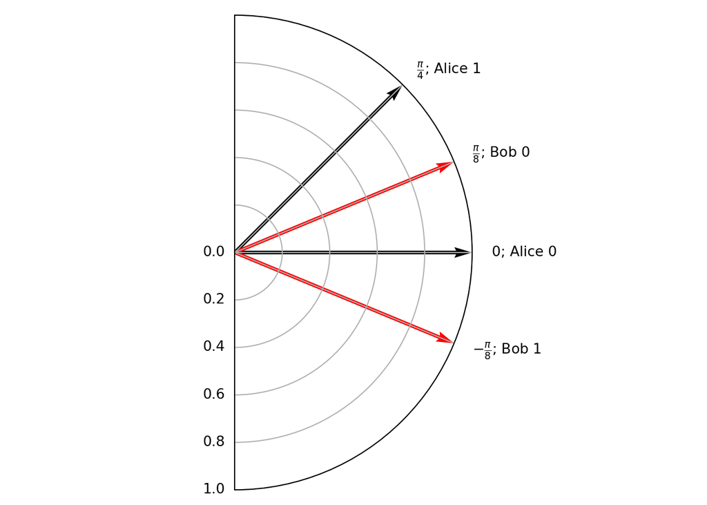

CHSH Inequality

| x | y | prob of $a = b$ |
| --- | --- | --- |
| 0 | 0 | $cos^2(\pi/8)$ |
| 0 | 1 | $cos^2(\pi/8)$ |
| 1 | 0 | $cos^2(\pi/8)$ |
| 1 | 1 | $cos^2(3\pi/8)$ |

So the probability of being successful is

$$\frac{3}{4}cos^2(\frac{\pi}{8}) + \frac{1}{4}[1-cos^2(\frac{3\pi}{8})] = cos^2(\frac{\pi}{8}) > \frac{3}{4}$$

Why?

First, the below can be generalized to any rotation.

$$\begin{aligned}
|\psi\rangle &= \frac{1}{\sqrt{2}}(|00\rangle + |11\rangle) \\
&= \frac{1}{\sqrt{2}}(|uu\rangle + |u^\perp u^\perp \rangle)
\end{aligned}$$
This can be shown by writing $|u\rangle$ and $|u^\perp \rangle$ as below, where $a$ and $b$ are real numbers.

$$|u\rangle = a|0\rangle + b|1\rangle \\
|u^\perp \rangle = -b|0\rangle + a|1\rangle.$$

Note: for the above rotational invariant to be true for any complex number $a$ and $b$, we need to start from

$$|\Psi^-\rangle = \frac{1}{\sqrt{2}}(|01\rangle - |10\rangle).$$

Second, given a state vector, the probability of measuring a basis vector is $cos^2\theta$, where $\theta$ is the angle between the state vector and basis vector. (Think of it as a projection.)

# 3 Appendix

*A bunch of stuff copied from the source mentioned at the beginning.*

If the position of the first particle were measured, the result of measuring the position of the second particle could be predicted. If instead the momentum of the first particle were measured, then the result of measuring the momentum of the second particle could be predicted.

They invoked a principle, later known as the “EPR criterion of reality,” positing that, “If, without in any way disturbing a system, we can predict with certainty (i.e., with probability equal to unity) the value of a physical quantity, then there exists an element of reality corresponding to that quantity.” From this, they inferred that the second particle must have a definite value of position and of momentum prior to either being measured. This contradicted the view associated with Niels Bohr and Werner Heisenberg, according to which a quantum particle does not have a definite value of a property like momentum until the measurement takes place.

Measuring one particle would alter the probability distribution of the other, yet here the other particle could not possibly be disturbed.

The authors claim that given a specific experiment, in which the outcome of a measurement is known before the measurement takes place, there must exist something in the real world, an “element of reality,” that determines the measurement outcome.

They postulate that these elements of reality are, in modern terminology, *local*, in the sense that each belongs to a certain point in spacetime. These claims are founded on assumptions about nature that constitute what is now known as *local realism*.

Bohr’s response to the EPR paper was published in the Physical Review later in 1935.[5] He argued that EPR had reasoned fallaciously. Because measurements of position and of momentum are complementary, making the choice to measure one excludes the possibility of measuring the other. Consequently, a fact deduced regarding one arrangement of laboratory apparatus could not be combined with a fact deduced by means of the other, and so, the inference of predetermined position and momentum values for the second particle was not valid. Bohr concluded that EPR’s “arguments do not justify their conclusion that the quantum description turns out to be essentially incomplete.”

For Einstein, the crucial part of the argument was the demonstration of nonlocality, that the choice of measurement done in particle A, either position or momentum, would lead to two different quantum states of particle B. He argued that, because of locality, the real state of particle B couldn’t depend on which kind of measurement was done in A, and therefore the quantum states cannot be in one-to-one correspondence with the real states.

The results obtained at one location are independentof any actions performed at space-like separation.

If you measure Particle A, it seems like Particle A’s quantum spin gets “set” by the measurement, but somehow Particle B also instantly “knows” what spin it is supposed to take on. To Einstein, this was a clear violation of the theory of relativity.

One of the key concepts on which Einstein, Podolski and Rosen base their argument is that of locality. These authors assume that if two systems are sufficiently apart, a measurement performed over one of the systems will not directly affect the reality of the other (unmeasured) system. However, Bell proved that quantum theory is non-local and that the EPR “paradox” is no more than a mere example of how Quantum Mechanics cannot be understood in classical physics terms.